# Assignment for 615 qixuan zhang

Qixuan Zhang

9/16/2018

## Assignment 1 for 615

Consider the following situation: A sloppy printer produces books with an average of 2 misprints per page. You want to know how many pages have more than k misprints in a book of n pages. Make an n x k table that shows the relationship between the total number of pages in a book and the number of pages with k misprints. Show and explain your work. Include equations and calculations to teach the reader how to solve the problem. Include an image of a book. Push your solution to a github repository and submit the url for repository on blackboard. Be sure your repo includes your document as a pdf file and as an RMD file. Include other files needed to recompile your document.

# Solution

# step 1 Calcualte the Poission distribution

$ P(X>k)$

```r
k <-0:10
probk <- ppois(k,lambda = 2,lower.tail=FALSE)
prob <- matrix(probk,nrow=1,ncol=11)
prob
```

```
##           [,1]      [,2]      [,3]      [,4]       [,5]       [,6]
## [1,] 0.8646647 0.5939942 0.3233236 0.1428765 0.05265302 0.01656361
##             [,7]        [,8]         [,9]        [,10]        [,11]
## [1,] 0.004533806 0.001096719 0.0002374473 4.649808e-05 8.308224e-06
```

# step2 Calculate

$ P(m<=n|misprints>k)$

```r
m<- matrix(1:50,nrow=50)
probr <- matrix(rep(0,length(k)*length(m)),nrow=length(m),ncol=length(k))
for(j in 1:length(k)){
  for(i in 1:length(m)){
    probr[i,j]=pbinom(m[i,],size=50,prob[,j])
  }
}

table=as.data.frame(matrix(probr,nrow=length(m),ncol=length(k),dimnames=list(c(1:50),c("k=0","k=1","k=2","k=3","k=4","k=5","k=6","k=7","k=8","k=9","k=10"))))


knitr::kable(table)
```

[output not shown]

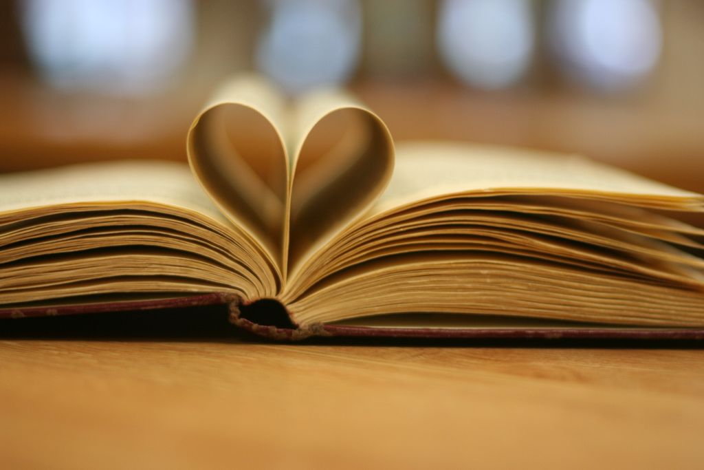